# eelgrass_fitness_modeling

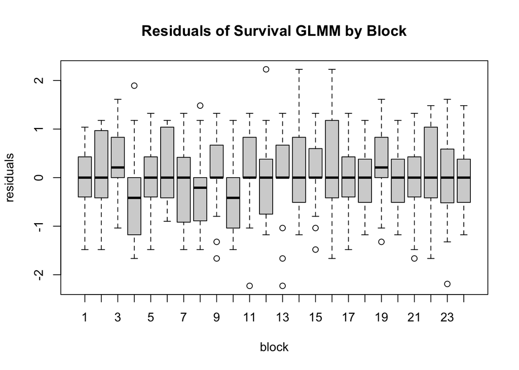

```r
# look for random effects in residuals
resid_surv <- data.frame(residuals = residuals(surv_glmm), block = fit_trim_env$block, tank_ID = fit_trim_env$tank_ID)
boxplot(residuals ~ block, data = resid_surv, main = "Residuals of Survival GLMM by Block") # boxplot bc block is a factor - doesn't look like any systematic effect of block
```

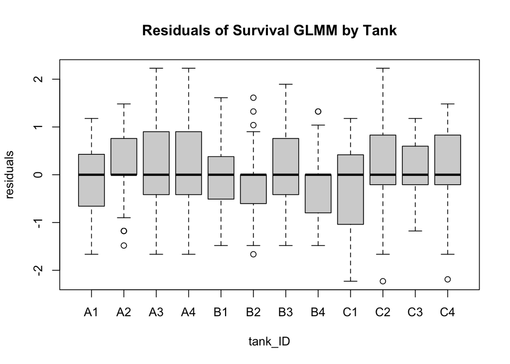

```r
boxplot(residuals ~ tank_ID, data = resid_surv, main = "Residuals of Survival GLMM by Tank") # tank also doesn't seem to have any systematic effects
```

```r
# significance testing with tukey
surv_glmm.1 <- glmer(isAlive ~ pop_trt + (1 | tank_ID), # getting boundary (singular) fit: see help('isSingular')
               family = binomial(link = "logit"),
               data = fit_trim)
```

```
## boundary (singular) fit: see help('isSingular')
```

```r
surv_glm_poptrt <- glm(isAlive ~ pop_trt,
                       family = binomial,
                       data = fit_trim_env)

tuk_surv <- TukeyHSD(aov(surv_glm_poptrt), conf.level = 0.95)
cld_surv <- multcompLetters4(aov(surv_glm_poptrt), tuk_surv)

# multcomp letters to get letters
letters_surv_df <- data.frame(letters = as.data.frame.list(cld_surv$pop_trt), popsite = names((cld_surv$pop_trt)$Letters))
letters_surv_df_red <- letters_surv_df[,c("letters.Letters","popsite")]
colnames(letters_surv_df_red) <- c("letters","popsite")
rownames(letters_surv_df_red) <- NULL
```

Rather than using treatment directly, I will try using salinity and temperature to represent temperature. Additionally, because tank_ID is confounded with temperature, I will try using x/y coordinates as a fixed effect and avoid having random effects altogether. If I do this, I can use a GLM.

```r
# anova
anova(lm(isAlive ~ pop + median_sal + median_temp, data = fit_trim_env)) # pop, sal, temp all significant
```

```
## Analysis of Variance Table
##
## Response: isAlive
##              Df Sum Sq Mean Sq  F value    Pr(>F)
## pop           7  4.438   0.634   4.7131 4.386e-05 ***
## median_sal    1 34.853  34.853 259.0671 < 2.2e-16 ***
## median_temp   1  5.995   5.995  44.5657 8.961e-11 ***
## Residuals   372 50.046   0.135
## ---
## Signif. codes:  0 '***' 0.001 '**' 0.01 '*' 0.05 '.' 0.1 ' ' 1
```

```r
# try a glm
surv_glm <- glm(isAlive ~ pop + median_sal + median_temp,
                family = binomial(link = "logit"),
                data = fit_trim_env)

# check dispersion & multicollinearity
check_overdispersion(surv_glm) # looks good
```

```
## # Overdispersion test
##
##  dispersion ratio = 1.000
##           p-value = 0.992
```

```
## No overdispersion detected.
```

```r
vif(surv_glm) # suggests no collinearity, everything is around 1
```

```
##                 GVIF Df GVIF^(1/(2*Df))
## pop         1.105963  7        1.007220
## median_sal  1.604122  1        1.266540
## median_temp 1.526863  1        1.235663
```

```r
# inspect model
summary(surv_glm)
```

```
##
## Call:
## glm(formula = isAlive ~ pop + median_sal + median_temp, family = binomial(link = "logit"),
##     data = fit_trim_env)
##
## Coefficients:
##              Estimate Std. Error z value Pr(>|z|)
## (Intercept)  5.841143   1.314271   4.444 8.81e-06 ***
## popBJO      -0.462520   0.556702  -0.831  0.40607
## popHOG      -0.006235   0.555026  -0.011  0.99104
## popHOR      -0.149827   0.554268  -0.270  0.78692
## popKAL       0.816855   0.575115   1.420  0.15551
## popKUR      -0.764350   0.564375  -1.354  0.17563
## popVAT      -1.911335   0.644577  -2.965  0.00302 **
## popVIK       1.141777   0.590198   1.935  0.05304 .
## median_sal   0.314807   0.036540   8.615  < 2e-16 ***
## median_temp -0.402947   0.062883  -6.408 1.48e-10 ***
## ---
## Signif. codes:  0 '***' 0.001 '**' 0.01 '*' 0.05 '.' 0.1 ' ' 1
##
## (Dispersion parameter for binomial family taken to be 1)
##
##     Null deviance: 528.89  on 381  degrees of freedom
## Residual deviance: 288.88  on 372  degrees of freedom
## AIC: 308.88
##
## Number of Fisher Scoring iterations: 6
```

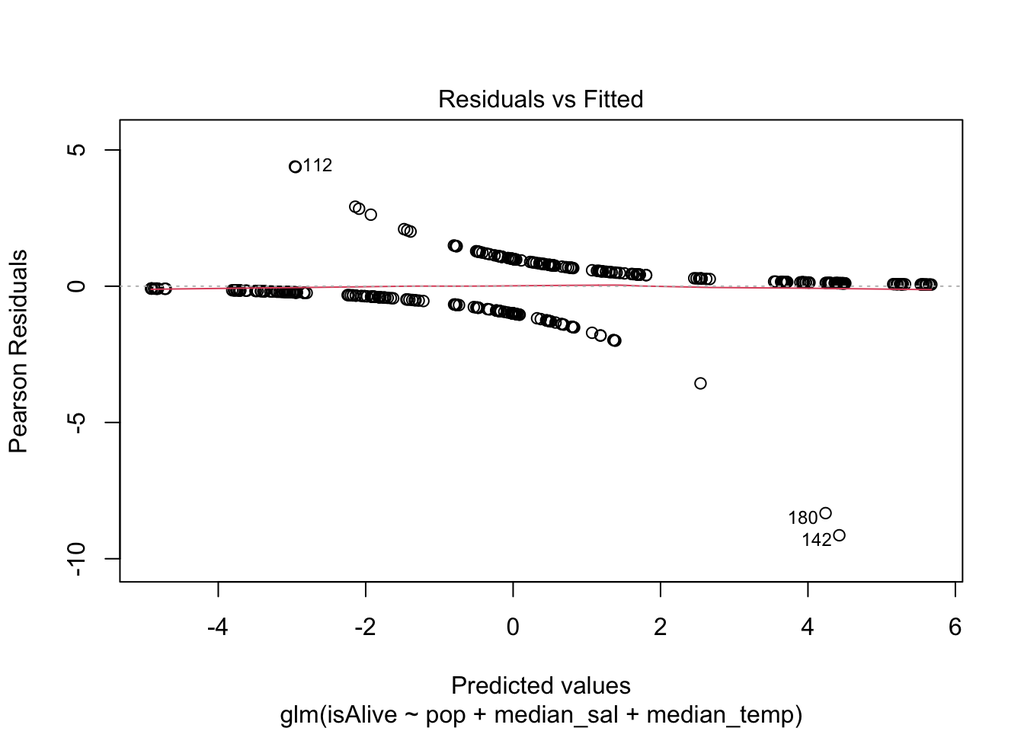

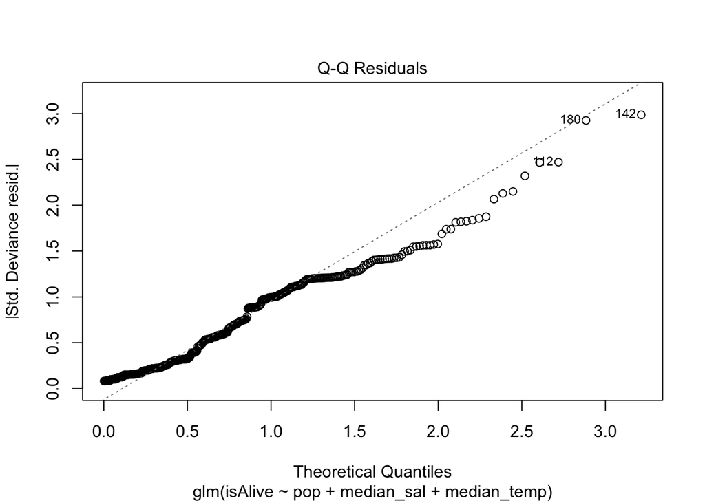

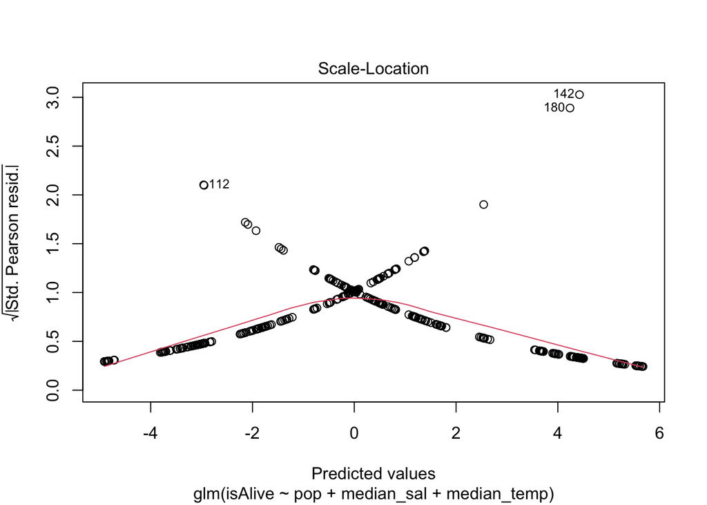

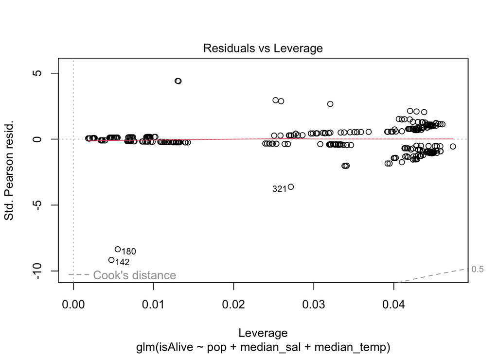

```r
plot(surv_glm)
```

```r
Anova(surv_glm, type = "III") # pop, sal, temp all signif
```

```
## Analysis of Deviance Table (Type III tests)
##
## Response: isAlive
##             LR Chisq Df Pr(>Chisq)
## pop           33.425  7  2.206e-05 ***
## median_sal   154.329  1  < 2.2e-16 ***
## median_temp   56.464  1  5.725e-14 ***
## ---
## Signif. codes:  0 '***' 0.001 '**' 0.01 '*' 0.05 '.' 0.1 ' ' 1
```

```r
step(surv_glm)
```

```
## Start:  AIC=308.88
## isAlive ~ pop + median_sal + median_temp
##
##               Df Deviance    AIC
## <none>             288.88 308.88
## - pop          7   322.31 328.31
## - median_temp  1   345.35 363.35
## - median_sal   1   443.21 461.21
```

```
##
## Call:  glm(formula = isAlive ~ pop + median_sal + median_temp, family = binomial(link = "logit"),
##     data = fit_trim_env)
##
## Coefficients:
## (Intercept)       popBJO       popHOG       popHOR       popKAL       popKUR
##    5.841143    -0.462520    -0.006235    -0.149827     0.816855    -0.764350
##      popVAT       popVIK   median_sal  median_temp
##   -1.911335     1.141777     0.314807    -0.402947
##
## Degrees of Freedom: 381 Total (i.e. Null);  372 Residual
## Null Deviance:       528.9
## Residual Deviance: 288.9     AIC: 308.9
```

```r
# what if we use block?
anova(lm(isAlive ~ pop + median_sal + median_temp + block, data = fit_trim_env)) # pop, sal, temp all significant
```

```
## Analysis of Variance Table
##
## Response: isAlive
##              Df Sum Sq Mean Sq  F value    Pr(>F)
## pop           7  4.438   0.634   4.6696 5.097e-05 ***
## median_sal    1 34.853  34.853 256.6756 < 2.2e-16 ***
## median_temp   1  5.995   5.995  44.1543 1.168e-10 ***
## block        23  2.657   0.116   0.8507    0.6657
## Residuals   349 47.389   0.136
## ---
## Signif. codes:  0 '***' 0.001 '**' 0.01 '*' 0.05 '.' 0.1 ' ' 1
```

```r
# try a glm
surv_glm_block <- glm(isAlive ~ pop + median_sal + median_temp + block,
                family = binomial(link = "logit"),
                data = fit_trim_env)

# check dispersion & multicollinearity
check_overdispersion(surv_glm_block) # looks good
```

```
## # Overdispersion test
##
##  dispersion ratio = 0.989
##           p-value = 0.872
```

```
## No overdispersion detected.
```

```r
vif(surv_glm_block) # suggests median sal has collinearity - this makes sense because the blocks align with salinity
```

```
##                   GVIF Df GVIF^(1/(2*Df))
## pop           1.238728  7        1.015409
## median_sal   93.599715  1        9.674695
## median_temp  12.195611  1        3.492222
## block       145.964932 23        1.114420
```

```r
# inspect model
summary(surv_glm_block)
```

```
##
## Call:
## glm(formula = isAlive ~ pop + median_sal + median_temp + block,
##     family = binomial(link = "logit"), data = fit_trim_env)
##
## Coefficients:
##              Estimate Std. Error z value Pr(>|z|)
## (Intercept) 17.311648   9.158309   1.890 0.058722 .
## popBJO      -0.498858   0.579014  -0.862 0.388928
## popHOG      -0.001623   0.581200  -0.003 0.997772
## popHOR      -0.167893   0.579054  -0.290 0.771860
## popKAL       0.907630   0.611414   1.484 0.137683
## popKUR      -0.835536   0.583931  -1.431 0.152464
## popVAT      -1.928443   0.646276  -2.984 0.002846 **
## popVIK       1.334024   0.640706   2.082 0.037332 *
## median_sal  -0.033779   0.281890  -0.120 0.904618
## median_temp -0.637170   0.184447  -3.454 0.000551 ***
## block2      -3.824912   3.674170  -1.041 0.297863
## block3       1.202376   1.127912   1.066 0.286415
## block4      -5.533175   3.770628  -1.467 0.142256
## block5      -0.173514   1.012319  -0.171 0.863907
## block6      -3.409733   3.648592  -0.935 0.350029
## block7      -0.664619   0.996728  -0.667 0.504899
## block8      -4.929340   3.744971  -1.316 0.188088
## block9       0.540562   1.049777   0.515 0.606602
## block10     -5.491274   3.742700  -1.467 0.142323
## block11      0.532039   1.051555   0.506 0.612889
## block12     -4.294319   3.674505  -1.169 0.242533
## block13      0.072395   1.040407   0.070 0.944525
## block14     -3.791228   3.647303  -1.039 0.298591
## block15      0.521651   1.049626   0.497 0.619198
## block16     -3.305192   3.612899  -0.915 0.360280
## block17      0.101963   1.018476   0.100 0.920254
## block18     -4.296139   3.691732  -1.164 0.244538
## block19      1.309111   1.129021   1.160 0.246248
## block20     -4.297224   3.700441  -1.161 0.245531
## block21      0.057495   1.013768   0.057 0.954773
## block22     -3.710140   3.627448  -1.023 0.306404
## block23      0.056634   1.013930   0.056 0.955457
## block24     -4.211411   3.645278  -1.155 0.247965
## ---
## Signif. codes:  0 '***' 0.001 '**' 0.01 '*' 0.05 '.' 0.1 ' ' 1
##
## (Dispersion parameter for binomial family taken to be 1)
##
##     Null deviance: 528.89  on 381  degrees of freedom
## Residual deviance: 271.83  on 349  degrees of freedom
## AIC: 337.83
##
## Number of Fisher Scoring iterations: 6
```

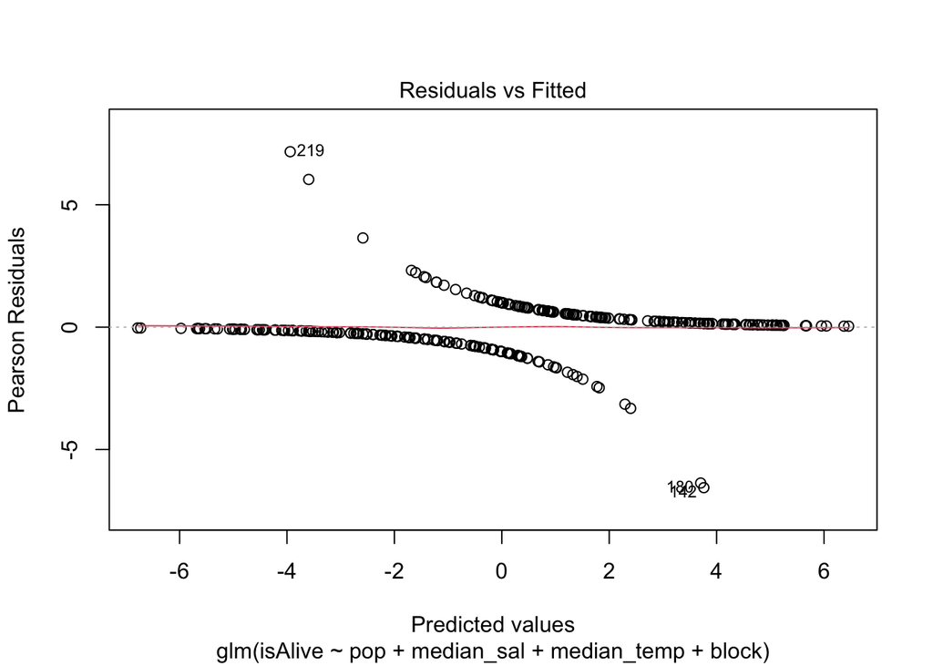

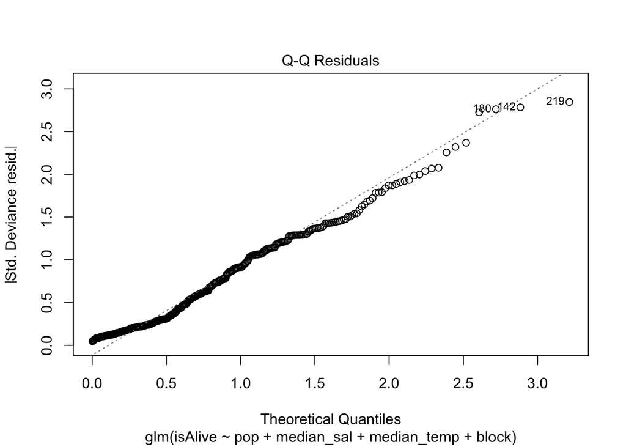

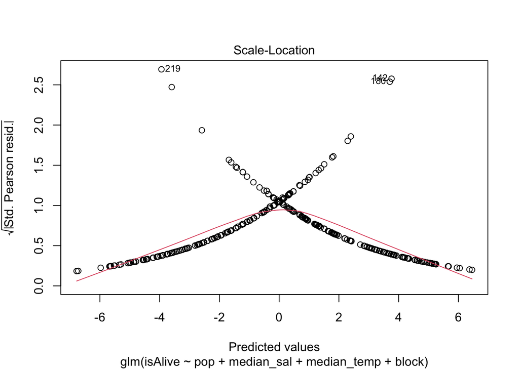

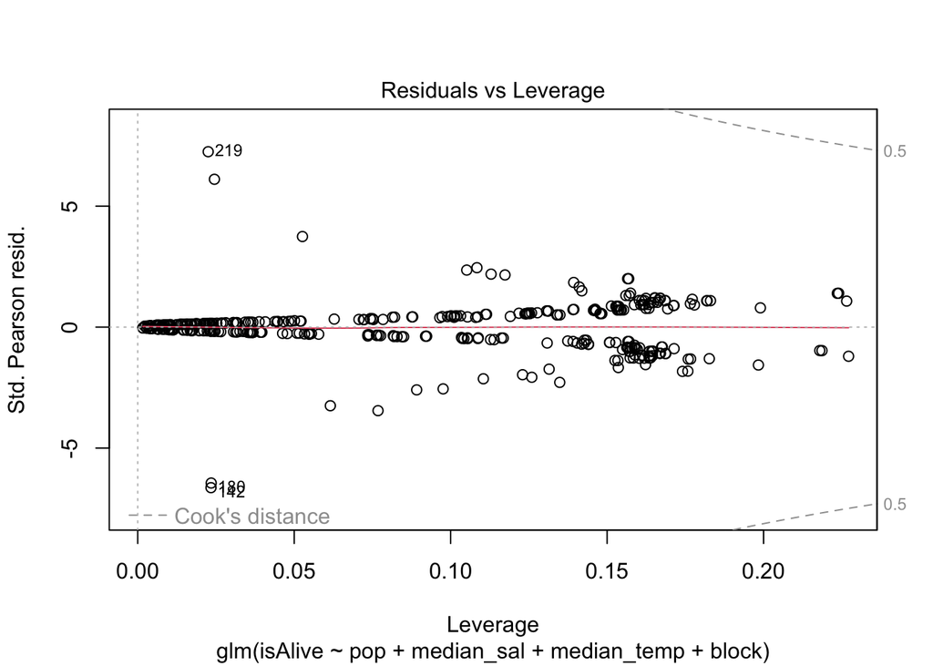

```r
plot(surv_glm_block)
```

```r
Anova(surv_glm_block, type = "III") # pop, temp signif
```

```
## Analysis of Deviance Table (Type III tests)
##
## Response: isAlive
##             LR Chisq Df Pr(>Chisq)
## pop           35.908  7  7.546e-06 ***
## median_sal     0.014  1  0.9047497
## median_temp   14.148  1  0.0001689 ***
## block         17.048 23  0.8068694
## ---
## Signif. codes:  0 '***' 0.001 '**' 0.01 '*' 0.05 '.' 0.1 ' ' 1
```

```r
# model selection
step(surv_glm_block) # gets rid of block, so back to the original (surv_glm)
```

```
## Start:  AIC=337.83
## isAlive ~ pop + median_sal + median_temp + block
##
##               Df Deviance    AIC
## - block       23   288.88 308.88
## - median_sal   1   271.85 335.85
## <none>             271.83 337.83
## - median_temp  1   285.98 349.98
## - pop          7   307.74 359.74
##
## Step:  AIC=308.88
## isAlive ~ pop + median_sal + median_temp
##
##               Df Deviance    AIC
## <none>             288.88 308.88
## - pop          7   322.31 328.31
## - median_temp  1   345.35 363.35
## - median_sal   1   443.21 461.21
```

```
##
## Call:  glm(formula = isAlive ~ pop + median_sal + median_temp, family = binomial(link = "logit"),
##     data = fit_trim_env)
##
## Coefficients:
## (Intercept)       popBJO       popHOG       popHOR       popKAL       popKUR
##    5.841143    -0.462520    -0.006235    -0.149827     0.816855    -0.764350
##      popVAT       popVIK   median_sal  median_temp
##   -1.911335     1.141777     0.314807    -0.402947
##
## Degrees of Freedom: 381 Total (i.e. Null);  372 Residual
## Null Deviance:       528.9
## Residual Deviance: 288.9     AIC: 308.9
```

### Growth Modeling

I will now model differences in growth, namely changes in length and changes in weight. I no longer need to use a GLMM, I can use an LMM since I am not working with a binary response variable. The following is for length growth (unstandardized)

```r
# start with length
# analysis of fixed effects
anova(lm(length_growth ~ pop + trt, data = fit_growth)) # both significant
```

```
## Analysis of Variance Table
##
## Response: length_growth
##            Df Sum Sq Mean Sq F value    Pr(>F)
## pop         7  86860 12408.6  10.338 6.109e-11 ***
## trt         3  52145 17381.8  14.481 1.601e-08 ***
## Residuals 187 224457  1200.3
## ---
## Signif. codes:  0 '***' 0.001 '**' 0.01 '*' 0.05 '.' 0.1 ' ' 1
```

```r
# now try building a model
growth_lmm <- lmer(length_growth ~ pop * trt + (1 | tank_ID), data = fit_growth)
```

```
## fixed-effect model matrix is rank deficient so dropping 5 columns / coefficients
```

```
## boundary (singular) fit: see help('isSingular')
```

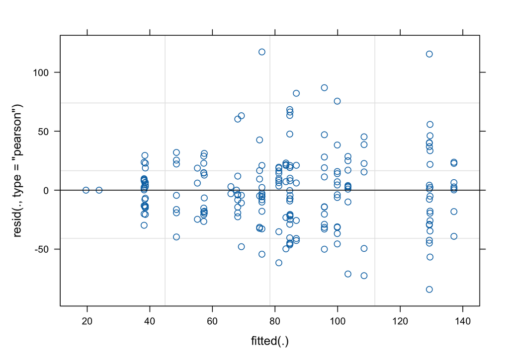

```r
plot(growth_lmm)
```

```r
Anova(growth_lmm, type = "III") # all signif except trt * pop
```

```
## Analysis of Deviance Table (Type III Wald chisquare tests)
##
## Response: length_growth
##              Chisq Df Pr(>Chisq)
## (Intercept) 95.836  1  < 2.2e-16 ***
## pop         30.954  7   6.34e-05 ***
## trt         11.565  3   0.009032 **
## pop:trt     24.457 16   0.079985 .
## ---
## Signif. codes:  0 '***' 0.001 '**' 0.01 '*' 0.05 '.' 0.1 ' ' 1
```

```r
drop1(growth_lmm) # drop interaction
```

```
## Single term deletions using Satterthwaite's method:
##
## Model:
## length_growth ~ pop * trt + (1 | tank_ID)
##         Sum Sq Mean Sq NumDF DenDF F value  Pr(>F)
## pop:trt  28086  1755.4    16   171  1.5286 0.09451 .
## ---
## Signif. codes:  0 '***' 0.001 '**' 0.01 '*' 0.05 '.' 0.1 ' ' 1
```

```r
summary(growth_lmm)
```

```
## Linear mixed model fit by REML. t-tests use Satterthwaite's method [
## lmerModLmerTest]
## Formula: length_growth ~ pop * trt + (1 | tank_ID)
##    Data: fit_growth
##
## REML criterion at convergence: 1738.2
##
## Scaled residuals:
##     Min      1Q  Median      3Q     Max
## -2.4849 -0.5905  0.0034  0.5535  3.4609
##
## Random effects:
##  Groups   Name        Variance Std.Dev.
##  tank_ID  (Intercept)    0      0.00
##  Residual             1148     33.89
## Number of obs: 198, groups:  tank_ID, 12
##
## Fixed effects:
##                            Estimate Std. Error       df t value Pr(>|t|)
## (Intercept)                  95.767      9.783  171.000   9.790  < 2e-16 ***
## popBJO                        4.125     13.835  171.000   0.298  0.76594
## popHOG                      -14.542     14.510  171.000  -1.002  0.31767
## popHOR                      -10.976     14.145  171.000  -0.776  0.43887
## popKAL                       33.542     13.835  171.000   2.424  0.01637 *
## popKUR                      -11.058     13.835  171.000  -0.799  0.42521
## popVAT                       33.752     14.145  171.000   2.386  0.01812 *
## popVIK                      -19.950     13.835  171.000  -1.442  0.15112
## trtTempControl_7psu          -8.967     16.944  171.000  -0.529  0.59735
## trtTempWarm_16psu           -47.267     16.117  171.000  -2.933  0.00382 **
## trtTempWarm_5psu            -71.967     35.271  171.000  -2.040  0.04285 *
## popBJO:trtTempControl_7psu   17.525     23.962  171.000   0.731  0.46556
## popHOG:trtTempControl_7psu    2.808     24.358  171.000   0.115  0.90835
## popHOR:trtTempControl_7psu    7.659     24.143  171.000   0.317  0.75145
## popKAL:trtTempControl_7psu   16.821     22.942  171.000   0.733  0.46445
## popKUR:trtTempControl_7psu   -6.492     25.882  171.000  -0.251  0.80226
## popVAT:trtTempControl_7psu -100.952     39.241  171.000  -2.573  0.01094 *
## popVIK:trtTempControl_7psu  -28.283     22.592  171.000  -1.252  0.21230
## popBJO:trtTempWarm_16psu    -14.205     24.189  171.000  -0.587  0.55782
## popHOG:trtTempWarm_16psu     23.279     22.763  171.000   1.023  0.30790
## popHOR:trtTempWarm_16psu     30.563     22.532  171.000   1.356  0.17675
## popKAL:trtTempWarm_16psu     21.258     21.978  171.000   0.967  0.33479
## popKUR:trtTempWarm_16psu     19.958     24.189  171.000   0.825  0.41047
## popVAT:trtTempWarm_16psu    -27.052     27.330  171.000  -0.990  0.32367
## popVIK:trtTempWarm_16psu      9.623     21.444  171.000   0.449  0.65419
## popHOG:trtTempWarm_5psu      58.442     50.073  171.000   1.167  0.24478
## popKAL:trtTempWarm_5psu       8.558     43.749  171.000   0.196  0.84514
## ---
## Signif. codes:  0 '***' 0.001 '**' 0.01 '*' 0.05 '.' 0.1 ' ' 1
```

```
##
## Correlation matrix not shown by default, as p = 27 > 12.
## Use print(x, correlation=TRUE)  or
##     vcov(x)        if you need it
```

```
## fit warnings:
## fixed-effect model matrix is rank deficient so dropping 5 columns / coefficients
## optimizer (nloptwrap) convergence code: 0 (OK)
## boundary (singular) fit: see help('isSingular')
```

```r
growth_lmm.1 <- lmer(length_growth ~ pop + trt + (1 | tank_ID), data = fit_growth)
```

```
## boundary (singular) fit: see help('isSingular')
```

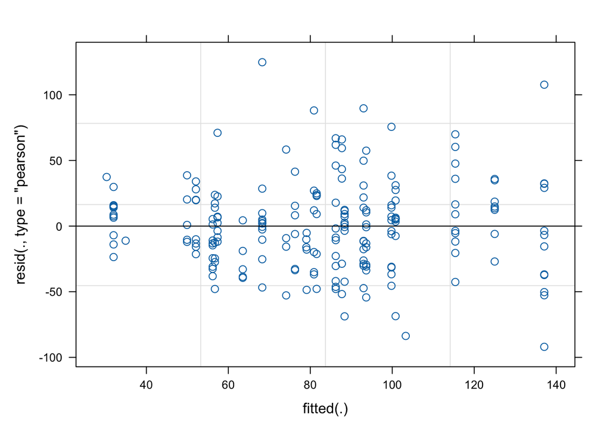

```r
plot(growth_lmm.1)
```

```r
Anova(growth_lmm.1, type = "III") # all signif
```

```
## Analysis of Deviance Table (Type III Wald chisquare tests)
##
## Response: length_growth
##               Chisq Df Pr(>Chisq)
## (Intercept) 161.191  1  < 2.2e-16 ***
## pop          70.979  7  9.367e-13 ***
## trt          43.443  3  1.981e-09 ***
## ---
## Signif. codes:  0 '***' 0.001 '**' 0.01 '*' 0.05 '.' 0.1 ' ' 1
```

```r
drop1(growth_lmm.1) # keep all
```

```
## Single term deletions using Satterthwaite's method:
##
## Model:
## length_growth ~ pop + trt + (1 | tank_ID)
##     Sum Sq Mean Sq NumDF DenDF F value    Pr(>F)
## pop  85196   12171     7   187  10.140 9.749e-11 ***
## trt  52145   17382     3   187  14.481 1.601e-08 ***
## ---
## Signif. codes:  0 '***' 0.001 '**' 0.01 '*' 0.05 '.' 0.1 ' ' 1
```

```r
summary(growth_lmm.1)
```

```
## Linear mixed model fit by REML. t-tests use Satterthwaite's method [
## lmerModLmerTest]
## Formula: length_growth ~ pop + trt + (1 | tank_ID)
##    Data: fit_growth
##
## REML criterion at convergence: 1890.5
##
## Scaled residuals:
##     Min      1Q  Median      3Q     Max
## -2.6553 -0.6480 -0.0225  0.4933  3.6029
##
## Random effects:
##  Groups   Name        Variance Std.Dev.
##  tank_ID  (Intercept)    0      0.00
##  Residual             1200     34.65
## Number of obs: 198, groups:  tank_ID, 12
##
## Fixed effects:
##                     Estimate Std. Error       df t value Pr(>|t|)
## (Intercept)          92.9970     7.3249 187.0000  12.696  < 2e-16 ***
## popBJO                6.8072     9.9471 187.0000   0.684  0.49461
## popHOG               -4.6309     9.7103 187.0000  -0.477  0.63399
## popHOR                0.6486     9.7313 187.0000   0.067  0.94693
## popKAL               44.0980     9.2306 187.0000   4.777 3.58e-06 ***
## popKUR               -6.7923    10.1990 187.0000  -0.666  0.50625
## popVAT               22.3925    11.3359 187.0000   1.975  0.04970 *
## popVIK              -24.7227     9.1880 187.0000  -2.691  0.00777 **
## trtTempControl_7psu -12.0981     6.3500 187.0000  -1.905  0.05829 .
## trtTempWarm_16psu   -36.2814     5.9439 187.0000  -6.104 5.84e-09 ***
## trtTempWarm_5psu    -58.0633    18.0230 187.0000  -3.222  0.00150 **
## ---
## Signif. codes:  0 '***' 0.001 '**' 0.01 '*' 0.05 '.' 0.1 ' ' 1
##
## Correlation of Fixed Effects:
##             (Intr) popBJO popHOG popHOR popKAL popKUR popVAT popVIK trTC_7
## popBJO      -0.648
## popHOG      -0.637  0.477
## popHOR      -0.647  0.481  0.489
## popKAL      -0.666  0.499  0.516  0.511
## popKUR      -0.641  0.461  0.465  0.469  0.485
## popVAT      -0.603  0.415  0.416  0.421  0.434  0.409
## popVIK      -0.672  0.509  0.519  0.523  0.543  0.495  0.441
## trtTmpCnt_7 -0.293  0.001 -0.018 -0.008 -0.030  0.041  0.113 -0.043
## trtTmpWr_16 -0.305  0.033 -0.034 -0.024 -0.027  0.037  0.079 -0.051  0.370
## trtTmpWrm_5 -0.150  0.071 -0.008  0.066 -0.055  0.074  0.078  0.064  0.129
##             tTW_16
## popBJO
## popHOG
## popHOR
## popKAL
## popKUR
## popVAT
## popVIK
## trtTmpCnt_7
## trtTmpWr_16
## trtTmpWrm_5  0.136
## optimizer (nloptwrap) convergence code: 0 (OK)
## boundary (singular) fit: see help('isSingular')
```

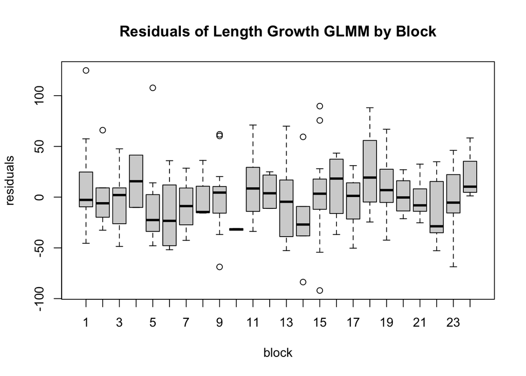

```r
# look for random effects in residuals
resid_growlen <- data.frame(residuals = residuals(growth_lmm.1), block = fit_growth$block, tank_ID = fit_growth$tank_ID)
boxplot(residuals ~ block, data = resid_growlen, main = "Residuals of Length Growth GLMM by Block") # here we do seem to have more variance in the data by block
```

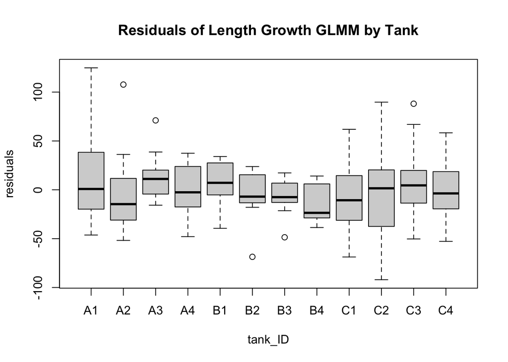

```r
boxplot(residuals ~ tank_ID, data = resid_growlen, main = "Residuals of Length Growth GLMM by Tank") # more variance by tank too, but nothing significantly different
```

```r
# significance testing with tukey - throws an error
#growth_lmm.2 <- lmer(length_growth ~ pop_trt + (1 | tank_ID), data = fit_growth) # singular, throws error
#tuk_len <- TukeyHSD(aov(growth_lmm.2), conf.level = 0.95) # invalid x type in x && y
#cld_len <- multcompLetters4(aov(growth_lmm.2), tuk_len)
```

```r
# analysis of fixed effects
anova(lm(length_std_change ~ pop + trt, data = fit_growth)) # both significant
```

```
## Analysis of Variance Table
##
## Response: length_std_change
##            Df  Sum Sq Mean Sq F value    Pr(>F)
## pop         7  57.408  8.2012  6.4519 8.156e-07 ***
## trt         3  38.068 12.6894  9.9829 3.901e-06 ***
## Residuals 187 237.699  1.2711
## ---
## Signif. codes:  0 '***' 0.001 '**' 0.01 '*' 0.05 '.' 0.1 ' ' 1
```

```r
# build a model
growlen_lmm <- lmer(length_growth ~ pop * trt + (1 | tank_ID), data = fit_growth)
```

```
## fixed-effect model matrix is rank deficient so dropping 5 columns / coefficients
```

```
## boundary (singular) fit: see help('isSingular')
```

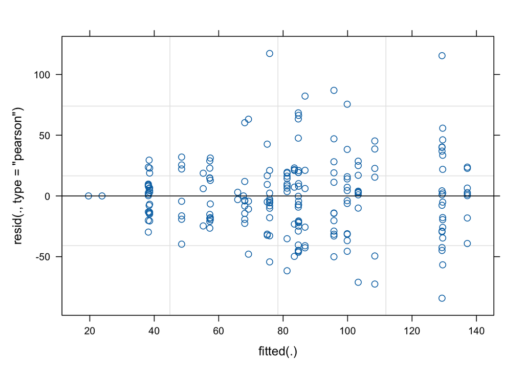

```r
plot(growlen_lmm)
```

```r
Anova(growlen_lmm, type = "III") # all signif except trt * pop
```

```
## Analysis of Deviance Table (Type III Wald chisquare tests)
##
## Response: length_growth
##              Chisq Df Pr(>Chisq)
## (Intercept) 95.836  1  < 2.2e-16 ***
## pop         30.954  7   6.34e-05 ***
## trt         11.565  3   0.009032 **
## pop:trt     24.457 16   0.079985 .
## ---
## Signif. codes:  0 '***' 0.001 '**' 0.01 '*' 0.05 '.' 0.1 ' ' 1
```

```r
drop1(growlen_lmm) # drop interaction
```

```
## Single term deletions using Satterthwaite's method:
##
## Model:
## length_growth ~ pop * trt + (1 | tank_ID)
##         Sum Sq Mean Sq NumDF DenDF F value  Pr(>F)
## pop:trt  28086  1755.4    16   171  1.5286 0.09451 .
## ---
## Signif. codes:  0 '***' 0.001 '**' 0.01 '*' 0.05 '.' 0.1 ' ' 1
```

```r
summary(growlen_lmm)
```

```
## Linear mixed model fit by REML. t-tests use Satterthwaite's method [
## lmerModLmerTest]
## Formula: length_growth ~ pop * trt + (1 | tank_ID)
##    Data: fit_growth
##
## REML criterion at convergence: 1738.2
##
## Scaled residuals:
##     Min      1Q  Median      3Q     Max
## -2.4849 -0.5905  0.0034  0.5535  3.4609
##
## Random effects:
##  Groups   Name        Variance Std.Dev.
##  tank_ID  (Intercept)    0      0.00
##  Residual             1148     33.89
## Number of obs: 198, groups:  tank_ID, 12
##
## Fixed effects:
##                            Estimate Std. Error       df t value Pr(>|t|)
## (Intercept)                  95.767      9.783  171.000   9.790  < 2e-16 ***
## popBJO                        4.125     13.835  171.000   0.298  0.76594
## popHOG                      -14.542     14.510  171.000  -1.002  0.31767
## popHOR                      -10.976     14.145  171.000  -0.776  0.43887
## popKAL                       33.542     13.835  171.000   2.424  0.01637 *
## popKUR                      -11.058     13.835  171.000  -0.799  0.42521
## popVAT                       33.752     14.145  171.000   2.386  0.01812 *
## popVIK                      -19.950     13.835  171.000  -1.442  0.15112
## trtTempControl_7psu          -8.967     16.944  171.000  -0.529  0.59735
## trtTempWarm_16psu           -47.267     16.117  171.000  -2.933  0.00382 **
## trtTempWarm_5psu            -71.967     35.271  171.000  -2.040  0.04285 *
## popBJO:trtTempControl_7psu   17.525     23.962  171.000   0.731  0.46556
## popHOG:trtTempControl_7psu    2.808     24.358  171.000   0.115  0.90835
## popHOR:trtTempControl_7psu    7.659     24.143  171.000   0.317  0.75145
## popKAL:trtTempControl_7psu   16.821     22.942  171.000   0.733  0.46445
## popKUR:trtTempControl_7psu   -6.492     25.882  171.000  -0.251  0.80226
## popVAT:trtTempControl_7psu -100.952     39.241  171.000  -2.573  0.01094 *
## popVIK:trtTempControl_7psu  -28.283     22.592  171.000  -1.252  0.21230
## popBJO:trtTempWarm_16psu    -14.205     24.189  171.000  -0.587  0.55782
## popHOG:trtTempWarm_16psu     23.279     22.763  171.000   1.023  0.30790
## popHOR:trtTempWarm_16psu     30.563     22.532  171.000   1.356  0.17675
## popKAL:trtTempWarm_16psu     21.258     21.978  171.000   0.967  0.33479
## popKUR:trtTempWarm_16psu     19.958     24.189  171.000   0.825  0.41047
## popVAT:trtTempWarm_16psu    -27.052     27.330  171.000  -0.990  0.32367
## popVIK:trtTempWarm_16psu      9.623     21.444  171.000   0.449  0.65419
## popHOG:trtTempWarm_5psu      58.442     50.073  171.000   1.167  0.24478
## popKAL:trtTempWarm_5psu       8.558     43.749  171.000   0.196  0.84514
## ---
## Signif. codes:  0 '***' 0.001 '**' 0.01 '*' 0.05 '.' 0.1 ' ' 1
```

```
##
## Correlation matrix not shown by default, as p = 27 > 12.
## Use print(x, correlation=TRUE)  or
##     vcov(x)        if you need it
```

```
## fit warnings:
## fixed-effect model matrix is rank deficient so dropping 5 columns / coefficients
## optimizer (nloptwrap) convergence code: 0 (OK)
## boundary (singular) fit: see help('isSingular')
```

```r
growlen_lmm.1 <- lmer(length_growth ~ pop + trt + (1 | tank_ID), data = fit_growth)
```

```
## boundary (singular) fit: see help('isSingular')
```

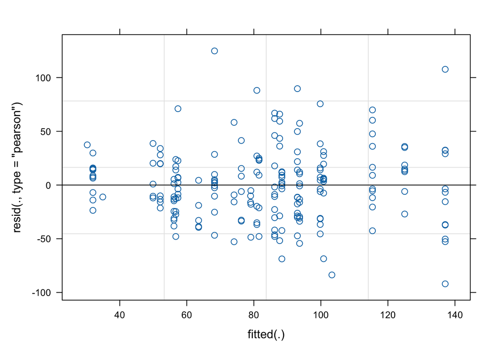

```r
plot(growlen_lmm.1)
```

```r
Anova(growlen_lmm.1, type = "III") # all signif
```

```
## Analysis of Deviance Table (Type III Wald chisquare tests)
##
## Response: length_growth
##               Chisq Df Pr(>Chisq)
## (Intercept) 161.191  1  < 2.2e-16 ***
## pop          70.979  7  9.367e-13 ***
## trt          43.443  3  1.981e-09 ***
## ---
## Signif. codes:  0 '***' 0.001 '**' 0.01 '*' 0.05 '.' 0.1 ' ' 1
```